# Diagnóstico e Monitoramento da Degradação Ambiental

Análise Ambiental · Aula 13.1

Prof. Dr. Luiz Diego Vidal Santos

## Abertura Visão Geral da Aula

**01 · Erosão Hídrica:** *splash*, erosão laminar, sulcos, ravinas e voçorocas.

**02 · Hidrodinâmica:** limiar de incisão ($\tau_0 > \tau_c$) e erosão interna subsuperficial (*piping/sapping*).

**03 · Geotecnia:** dinâmica de recuo de cabeceiras (*headcut retreat*) em voçorocas.

**04 · Monitoramento:** protocolos auditáveis com pinos de erosão, estacas e VANT (SfM / DoD).

**05 · Degradação Fluvial:** solapamento de margens, assoreamento e desconexão de planície.

**06 · Terras Secas e Pastagens:** compactação, salinização, desertificação e recuperação vs. renovação.

Objetivo da Aula Mecanismos físicos e métricas de campo

Diagnosticar os mecanismos físicos, hidráulicos e geotécnicos que governam a evolução das feições erosivas lineares (sulcos, ravinas e voçorocas), a instabilidade de margens fluviais e a salinização de solos, aplicando métodos quantitativos de monitoramento em campo.

Tensão Cisalhante Piping & Headcut Pinos & VANT/DoD Salinização

# Evolução Mecanística da Erosão Hídrica

## Erosão Linear Do Impacto da Gota (*Splash*) à Voçoroca

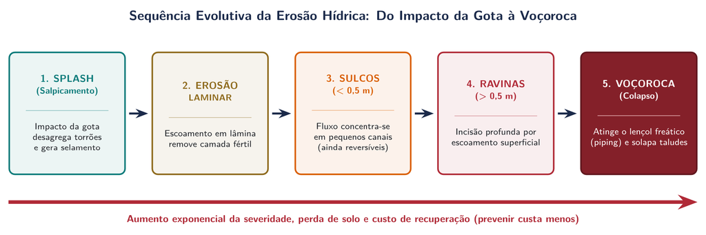

Evolução mecanística da erosão hídrica superficial e subsuperficial, recuo de cabeceira de voçoroca e métodos de monitoramento geomorfológico em campo.

Sequência evolutiva da erosão hídrica: do salpicamento à voçoroca Transição entre processos difusos, incisão linear concentrada, piping freático e colapso de taludes

## Diagnóstico Diagnosticar feições e processos erosivos

| Evidência | Interpretação a investigar |
| --- | --- |
| **Salpicamento e selamento** | Desagregação por chuva e redução da infiltração |
| **Remoção entre sulcos** | Transporte por escoamento superficial difuso |
| **Sulcos** | Concentração do fluxo em pequenas incisões |
| **Ravinas e voçorocas** | Incisões persistentes com cabeceiras, paredes e conexões próprias |

Critério terminológico Definir dimensões e atividade

Os limites dimensionais e o emprego de “ravina” e “voçoroca” variam na literatura. Declarar o critério adotado e descrever largura, profundidade, extensão, atividade e mecanismos.

Cautela diagnóstica Não inferir só pela geometria

Fluxos superficiais e subsuperficiais podem coexistir. Lençol freático ou *piping* devem ser demonstrados; formato em U ou V não prova sozinho o mecanismo, nem há sequência linear obrigatória.

# Hidrodinâmica e Geotecnia do Voçorocamento

## Voçorocas O que diferencia uma Voçoroca e por que estudar seus Mecanismos?

Escala do corte Do escoamento difuso ao canal incisivo

Enquanto a erosão laminar e os sulcos rasos dependem sobretudo da chuva e do escoamento superficial, o voçorocamento envolve cortes profundos no solo e no saprolito com participação frequente do lençol freático e da estabilidade geotécnica das paredes.

Base para o PRAD Por que quantificar forças e fluxos internos?

O sucesso de qualquer obra de contenção ou PRAD depende de saber se a feição avança por **força trativa na base ($\tau_0$)**, por **escoamento subsuperficial (*piping* e *sapping*)** ou por **colapso de taludes**.

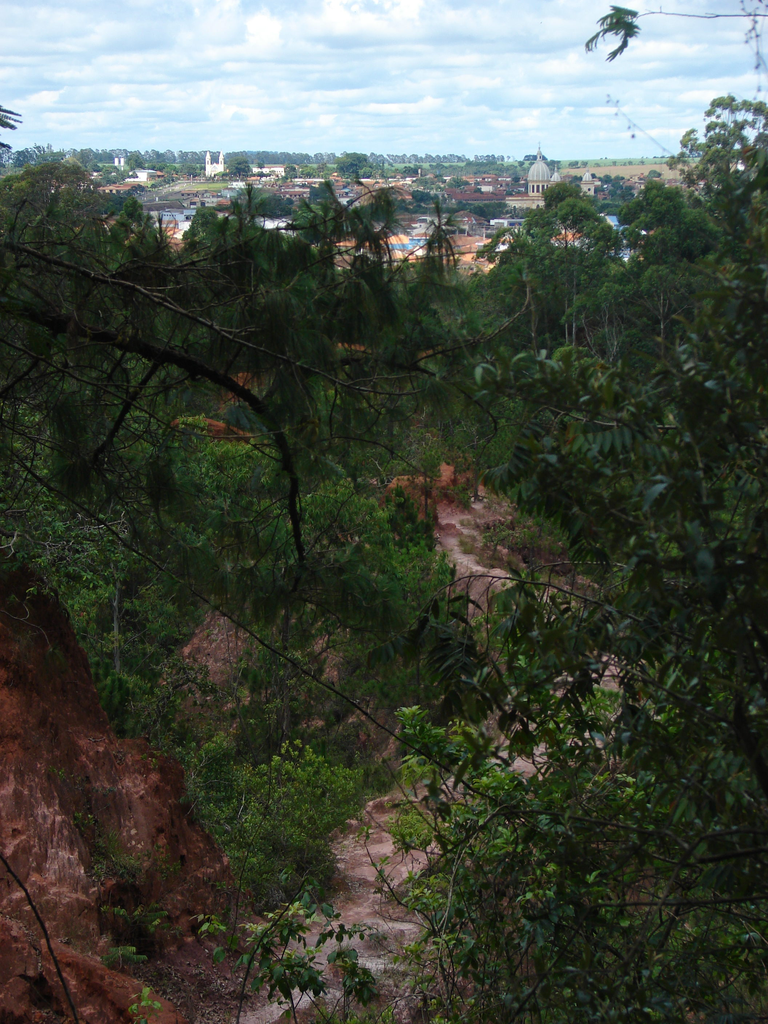

Exemplo de voçoroca de grande porte em campo (Casa Branca, SP). Fonte: Wikimedia Commons.

Voçoroca de grande porte em campo (Casa Branca, SP) Fonte: Wikimedia Commons · incisão profunda e instabilidade geotécnica das paredes

## Hidrodinâmica Incisão, erosão interna e recuo de cabeceira

Para fluxo aproximadamente uniforme, a tensão cisalhante hidráulica na base ($\tau_0$) desencadeia incisão quando supera a resistência crítica do material ($\tau_c$):

$$\tau_0 = \rho_w g R_h S_f = \gamma R_h S_f > \tau_c$$

$R_h$: raio hidráulico ($\text{m}$); $S_f$: declividade da linha de energia ($\text{m/m}$); $\gamma = \rho_w g$: peso específico da água; resultado em $\text{Pa}$, comparado a $\tau_c$ medido ou estimado para o material.

01 · Headcut Recuo de cabeceira

Degrau erosivo pode recuar por impacto, escavação basal e colapso.

02 · Piping Erosão interna

Remoção interna de partículas com formação ou ampliação de dutos.

03 · Sapping Exfiltração

Erosão associada à descarga subterrânea na superfície do talude.

04 · Rupturas Colapso de paredes

Dependem de material, geometria, água e perda de apoio basal.

Nem todo saprolito é friável; nem toda voçoroca apresenta exfiltração permanente. Registrar chuvas, surgências e mudanças sazonais.

# Monitoramento Morfométrico Auditável

## Monitoramento Pinos e estacas: um protocolo reproduzível

**01 · Orientação:** definir a superfície e a direção medida (vertical ou normal ao talude).

**02 · Linha de base:** instalar referências estáveis e registrar exposição inicial e posição.

**03 · Periodicidade:** repetir as leituras após eventos e exatamente na mesma orientação.

**04 · Ocorrências:** registrar deslocamento, pisoteio, perdas e deposição junto à haste.

**05 · Relato:** apresentar variação, dispersão, número de pinos e período amostral.

Limites de interpretação Leitura pontual vs. bacia

Exposição maior pode indicar remoção; menor pode indicar deposição. Movimentação da haste ou do bloco invalida a interpretação simples.

A mudança local da superfície **não equivale ao sedimento exportado da bacia hidrográfica**.

## Monitoramento Quando converter espessura em massa?

Para uma **lâmina média representativa da área**, com densidade aparente do solo ($D_s$) conhecida:

$$M\;(\mathrm{t/ha}) = 10\,h\;(\mathrm{mm})\,D_s\;(\mathrm{g/cm^3})$$

**Exemplo didático:** $h = 5\text{ mm}$ e $D_s = 1{,}30\text{ g/cm}^3 \implies M = 65\text{ t/ha}$.

A relação exige área de referência e geometria compatíveis. Uma leitura normal a uma parede não é uma lâmina vertical sobre um hectare. Explicitar se o resultado representa mudança líquida, remoção bruta ou deposição; não chamar automaticamente de produção de sedimentos.

## VANT / SfM Fotogrametria e modelo de diferença (DoD)

Modelo Digital de Diferença de Elevação (*DEM of Difference*):

$$DoD = MDE_{t_2} - MDE_{t_1}$$

Protocolo fotogramétrico Rastreabilidade e incerteza

- Usar a mesma referência, corregistrar modelos e verificar pontos de controle independentes.
- Separar vegetação e superfície do terreno.
- Estimar o limite de detecção e propagar a incerteza.
- Integrar diferenças negativas e positivas apenas onde o sinal é confiável.

Restrições geométricas Limites do MDE 2.5D

Um MDE representa uma altura por posição horizontal e pode falhar em paredes verticais, saliências e áreas ocultas.

Resolução centimétrica **não garante acurácia centimétrica nem volume “exato”**.

# Degradação Fluvial e Salinização

## Canais Fluviais Degradação Hidrossedimentológica de Canais Fluviais

Solapamento de barrancos Erosão Marginal

Causada pela remoção da mata ciliar (perda da coesão radicular $c_r$ e da rugosidade hidráulica), pelo pisoteio direto do gado na margem (desagregação) e pela oscilação rápida do nível d’água (poropressão residual no rebaixamento da cheia).

Aggradation Assoreamento

Quando a carga sólida entregue pelas vertentes erodidas supera a **capacidade de transporte do rio**, areia e cascalho depositam-se no leito em bancos e barras. A calha torna-se rasa e larga, reduzindo o volume útil de reservatórios e elevando a frequência de transbordamentos.

## Terras Secas Salinização e Sodificação de Solos no Semiárido

Ocorre em baixadas e perímetros irrigados ($ETP \gg P$, Vale do São Francisco e açudes do Sertão) com **irrigação salobra e ausência de drenagem subsuperficial**: a **ascensão capilar** precipita crostas brancas ($\text{NaCl, CaSO}_4, \text{MgSO}_4$).

Richards, 1954 / Embrapa Solo Salino

Condutividade Elétrica do extrato de saturação $CE_{es} \ge 4\text{ dS/m}$ e Percentagem de Sódio Trocável $PST < 15\%$.

Dispersão estrutural Solo Sódico (Alcalino)

$PST \ge 15\%$ e $CE_{es} < 4\text{ dS/m}$: o íon $\text{Na}^+$ dispersa as argilas, destrói a estrutura física e pode reduzir a infiltração, dependendo da mineralogia e concentração de eletrólitos.

Dupla restrição Solo Salino-Sódico

$CE_{es} \ge 4\text{ dS/m}$ e $PST \ge 15\%$: combina estresse osmótico severo com risco de colapso estrutural se lixiviado sem corretivo de cálcio.

## Risco Socioambiental Do processo ao risco socioambiental

**Caso:** incisão ativa próxima de estrada e moradias.

| Etapa | Evidência |
| --- | --- |
| **Processo e tendência** | Recuo de cabeceira, seções, chuva e histórico |
| **Área potencialmente atingida** | Geometria e cenários fundamentados |
| **Exposição** | Pessoas, acessos, água e infraestrutura |
| **Vulnerabilidade** | Condições das edificações, mobilidade e resposta |
| **Ação** | Comunicação com órgãos responsáveis e prioridades de proteção |

Não extrapolar uma taxa medida em um ponto para toda a feição. Registrar a incerteza e distinguir diagnóstico de projeto executivo.

# Degradação da Cobertura Vegetal e Recuperação

## Pastagens Níveis de Degradação do Solo sob Pastagens

| Grau | Barcellos (1986) | Dias-Filho (2011) |
| --- | --- | --- |
| **1** | Redução de produção | Perda de vigor e solo pouco descoberto |
| **2** | Grau 1 + redução da cobertura | Nível 1 agravado + plantas daninhas (PD) |
| **3** | Graus 1 e 2 + invasoras + leve erosão | Nível 2 + morte da forrageira |
| **4** | Grau 3 + invasoras + pasto nativo + erosão | Solo descoberto + erosão física |

| Autor / Critério | Faixas de Classificação |
| --- | --- |
| **Serrão & Toledo (1990)** *(% de plantas daninhas, PD)* | **Até 10%:** não degradado **10% a 35%:** baixo · **35% a 80%:** médio **80% ou mais:** alto |
| **Nascimento Jr. (1994)** *(Produtividade relativa)* | **75% a 100%:** excelente (não degradada) **50% a 75%:** boa · **25% a 50%:** ruim **Menor que 25%:** degradada |

## Recuperação Estratégias de Intervenção: Recuperação vs. Renovação

Graus 1 e 2 Recuperação Direta

Restabelecer a produção forrageira **mantendo a mesma espécie ou cultivar** por meio de práticas simples de manejo:

1. Ajuste no manejo do pasto;
2. Controle de plantas invasoras;
3. Correção da fertilidade do solo;
4. Introdução de leguminosas;
5. Sobressemeadura da espécie já existente (no florescimento).

Graus 3 e 4 Intervenção Estrutural e Renovação

Perda severa de cobertura e presença de erosão exigem ações mais onerosas:

- **Renovação:** substituição da espécie/cultivar ou reintrodução da forrageira;
- **Alternativas complementares:** implantação de **Sistema Agrossilvopastoril** ou **pousio da pastagem** (descanso programado).

**Objetivo:** restabelecer vigor, qualidade e produtividade, obtendo um sistema sustentável e viável.

# Síntese e Referências

## Síntese Síntese Operacional para Diagnósticos e PRAD

01 · Protocolo descritivo Ravinas e voçorocas

Descrever geometria, atividade, conectividade e participação dos fluxos superficiais e subsuperficiais; declarar o critério terminológico adotado.

02 · Erro crítico em PRAD Nunca aterrar sem drenagem

Jamais aterrar uma voçoroca com solo solto sem antes **disciplinar o escoamento superficial na cabeceira (crista)** e **drenar o fluxo freático na base**, sob pena de nova ruptura imediata.

03 · Auditoria Pinos de erosão e VANT (DoD)

Transformam descrições subjetivas em **métricas volumétricas e gravimétricas auditáveis ($\text{m}^3$ e $\text{t/ha/ano}$)**.

## Referências Referências Bibliográficas

Bibliografia da Aula Erosão, geotecnia, monitoramento e pastagens

- AUGUSTO FILHO, O. Caracterização geológico-geotécnica voltada à estabilização de encostas. In: **COBRAE**, 1., 1992, Rio de Janeiro. Anais… ABMS/ABGE, 1992. p. 721–733.
- BARCELLOS, A. O. Recuperação de pastagens degradadas. In: **Simpósio sobre Manejo da Pastagem**, 8., 1986, Piracicaba. Anais… FEALQ, 1986.
- DIAS-FILHO, M. B. **Degradação de pastagens: processos, causas e estratégias de recuperação**. 4. ed. Belém: Mb Agro, 2011.
- GUERRA, A. J. T.; SILVA, A. S.; BOTELHO, R. G. M. (Orgs.). **Erosão e Conservação dos Solos: conceitos, temas e aplicações**. 9. ed. Rio de Janeiro: Bertrand Brasil, 2014.
- MORGAN, R. P. C. **Soil Erosion and Conservation**. 3. ed. Oxford: Blackwell Publishing, 2005.
- NASCIMENTO JÚNIOR, D.; QUEIROZ, D. S.; SANTOS, M. V. F. Degradação das pastagens e critérios para avaliação. In: **Simpósio sobre Manejo da Pastagem**, 11., 1994, Piracicaba. Anais… FEALQ, 1994. p. 107–151.
- OLIVEIRA, M. A. T. Processos erosivos e preservação de áreas de risco de erosão por voçorocas. In: GUERRA, A. J. T. et al. **Erosão e Conservação dos Solos**. Rio de Janeiro: Bertrand Brasil, 1999. p. 57–99.
- SERRÃO, E. A. S.; TOLEDO, J. M. The search for sustainability in Amazonian pastures. In: ANDERSON, A. B. (Ed.). **Alternatives to deforestation**. New York: Columbia University Press, 1990. p. 195–214.